# Lab: ggplot

36-600

Fall 2022

## Data

We’ll importing the same data that we used for the `dplyr` lab, with rows with data with value 99 (i.e., rows with missing data) removed:

```r
suppressMessages(library(tidyverse))
rm(list=ls())
file.path = "https://raw.githubusercontent.com/pefreeman/36-290/master/EXAMPLE_DATASETS/BUZZARD/Buzzard_DC1.Rdata"
load(url(file.path))
set.seed(101)
s = sample(nrow(df),4000)
df = df[s,]
df %>% filter(.,u!=99&g!=99&r!=99&i!=99&z!=99&y!=99) -> df.new
predictors = df.new[,-c(7:14)]
redshift   = as.vector(df.new[,14])

type = rep("FAINT",nrow(predictors))
w = which(predictors$i<25)
type[w] = "BRIGHT"
type = factor(type)
predictors = cbind(type,predictors)

df = cbind(predictors,redshift)
```

If everything loaded correctly, you should see a variable in your global environment called `df`, a data frame with 3607 rows and 8 columns.

```r
dim(df)
```

```
## [1] 3607    8
```

## ggplot

We will use `ggplot` to create our plots. In order to become comfortable quickly with `ggplot`, you should read through Chapter 3 (online; Chapter 1 in print) of *R for Data Science* by Wickham and Grolemund, available for free [here](http://r4ds.had.co.nz/).

The following is an example of a `ggplot` call:

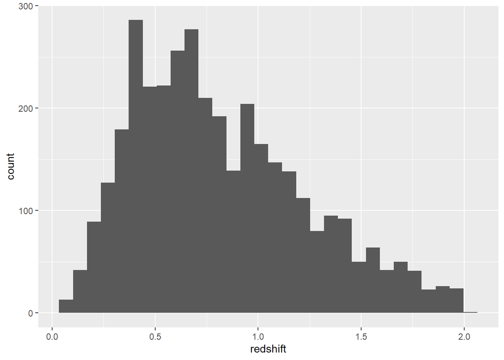

```r
ggplot(data=df,mapping=aes(x=redshift)) +
  geom_histogram() # ignore the picky complaint about bins
```

Note the structure here: the first function is `ggplot()`, and you pass a data frame (as `data`) and an identification of which feature goes along which axis (as `mapping`). Once you’ve identified the data and the mapping, you “add on” another function that describes what you will do to the data; in this case, that function is `geom_histogram()`.

# Questions

## Question 1

Re-run ggplot from above, setting the number of bins to be 60. (Use the documentation for `geom_histogram()` to figure out how to do this…e.g., type `?geom_histogram` in the Console pane.) Also, change the color of the histogram via the `fill` argument. Google “R colors” to find listings of the names of `R`’s colors. My personal favorite is “papayawhip”.

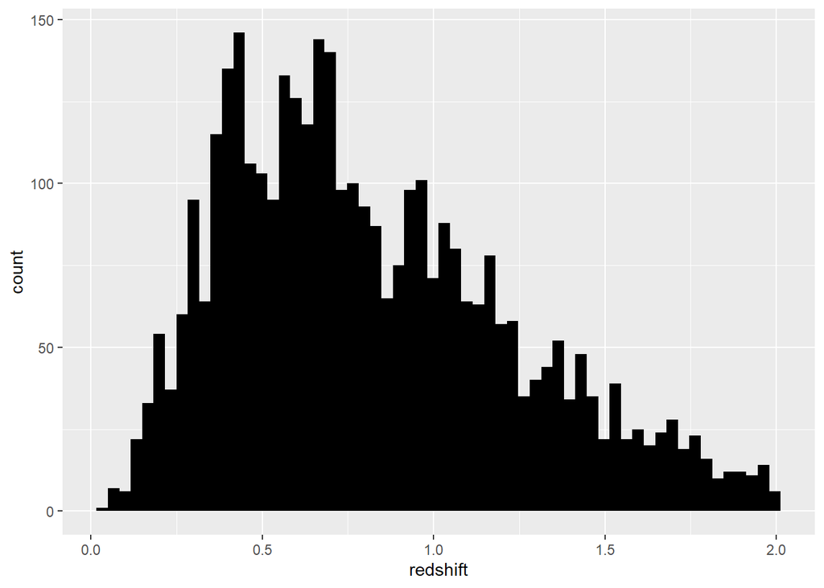

```r
# FILL ME IN
ggplot(data=df,mapping=aes(x=redshift)) +
  geom_histogram(bins=60,fill="black")
```

## Question 2

Repeat Question 1, but change the x-axis label to “Redshift z” and the y-axis label to “Number of Galaxies at Redshift z”. Also, add a title to the plot: “Redshift Distribution for Buzzard DC1 Data”. Google phrases like “how to add a title to ggplot”. Trust me: Googling is the fastest way to figure out what function does what in the `ggplot` world.

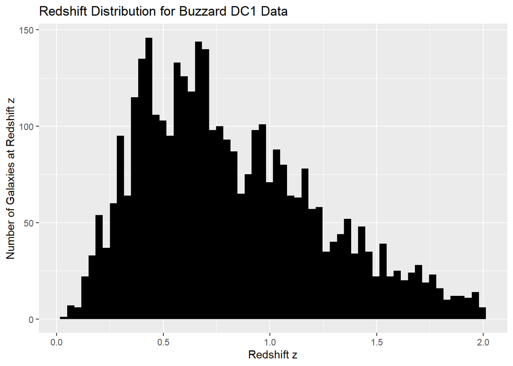

```r
# FILL ME IN
ggplot(data=df,mapping=aes(x=redshift)) +
  geom_histogram(bins=60,fill="black") +
  ggtitle("Redshift Distribution for Buzzard DC1 Data")+
  labs(y='Number of Galaxies at Redshift z', x = 'Redshift z')
```

## Question 3

Construct a bar chart that shows the distribution of galaxy `type`, here defined to be `BRIGHT` and `FAINT`. Remember that a bar chart is a representation of a probability mass function. As a reminder to yourself, also show the number of counts for each type, coded in some manner that you’ve learned thus far.

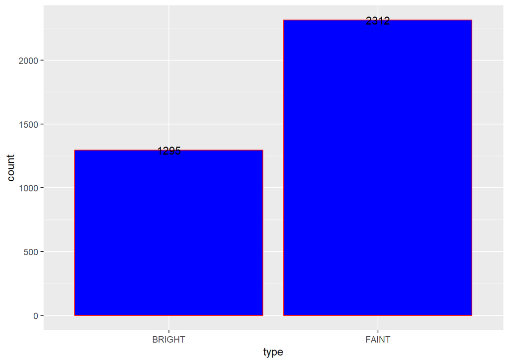

```r
# FILL ME IN
new <- df %>% dplyr::group_by(type) %>% summarise(.,count=n())

ggplot(data=df,mapping=aes(x=type)) + geom_bar(color="red",fill="blue") + geom_text(mapping =aes(x=type,y=count,label=count), data = new, stat = "identity")
```

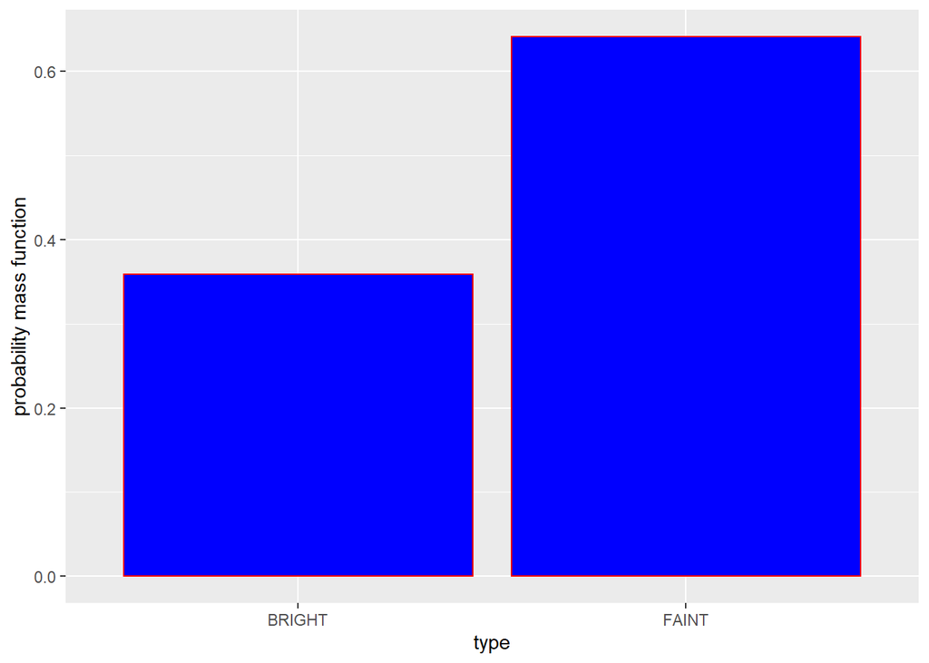

```r
ggplot(data=new,mapping=aes(x=type,y=count/sum(count))) + geom_bar(stat='identity',color="red",fill="blue")  + labs(y='probability mass function')
```

## Question 4

Utilize facet wrapping to display two histograms side-by-side: one showing `u`-band magnitudes for `BRIGHT` data, and one showing `u`-band magnitudes for `FAINT` data. Note that to compare distributions, it is helpful *to have the data span the same scale*. So add a function to the string of functions that sets the x-axis limits to be 20 and 32.

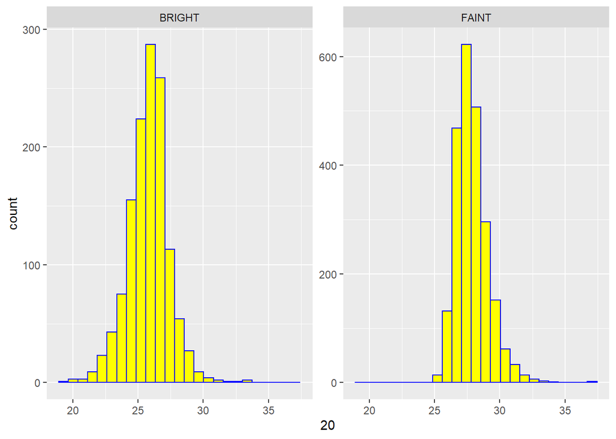

```r
# FILL ME IN
ggplot(data=df,mapping=aes(x=u)) +
geom_histogram(color="blue",fill="yellow",bins=25) +
facet_wrap(~type,scales='free_y') +
scale_x_continuous(c(20,32))
```

## Question 5

Show the same information as in Question 4, except use overlapping, partially transparent histograms. Construct such a histogram (again for `u`). (Hints: in the call to `aes()` in the `ggplot()` call, include `fill=type`, and in the `geom_histogram()` call, include two new arguments: `alpha` and `position="Identity"`. The `alpha` argument controls the transparency: 0 for invisible to 1 for totally opaque.

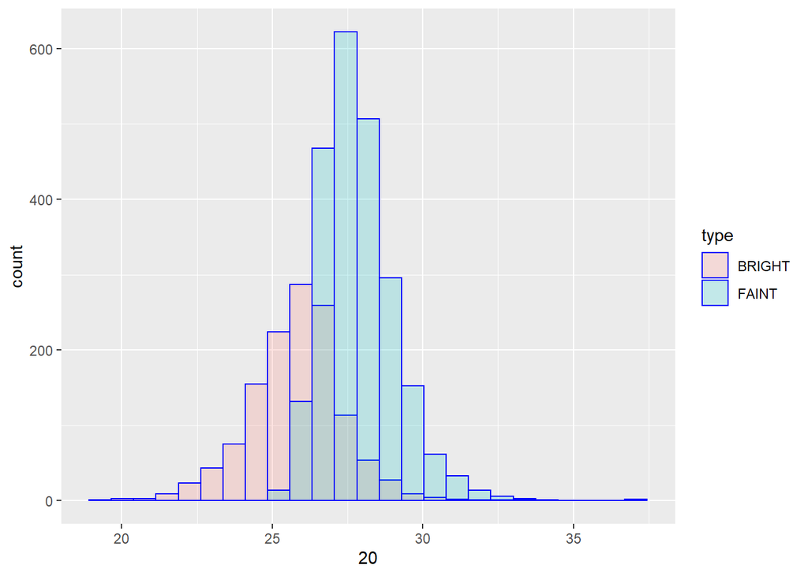

```r
# FILL ME IN
ggplot(data=df,mapping=aes(x=u,fill=type)) +
geom_histogram(color="blue",bins=25,alpha=0.2,position='Identity') +
scale_x_continuous(c(20,32))
```

## Question 6

Show the same information as in Question 4, except that instead of using side-by-side histograms, use side-by-side boxplots. Unlike in Question 4, you do not need to apply `facet_wrap()`. Instead, for the aesthetics, specify that `x` is `type` and `y` is `u`.

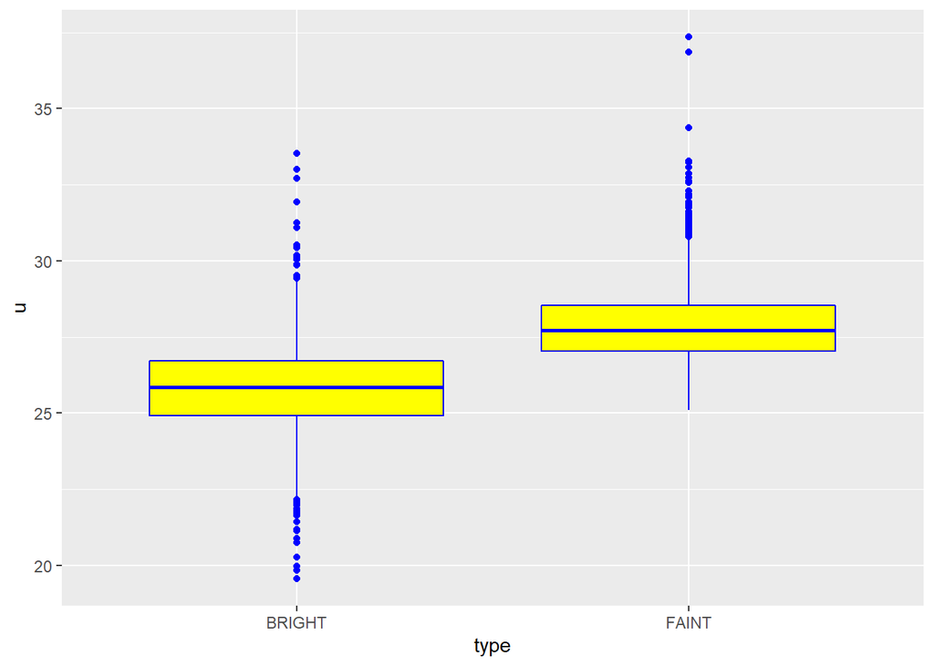

```r
# FILL ME IN
ggplot(data=df,mapping=aes(x=type,y=u)) +
geom_boxplot(color="blue",fill="yellow")
```

## Question 7

Create a faceted histogram for the `u`, `g`, `r`, `i`, `z`, and `y` columns in the `df` data frame. This means you’ll want to pipe `df` to `select()` (or, perhaps, `dplyr::select()`), then to `gather()`, and save the output to a new variable, then you’ll want to pass this new data frame into `ggplot()`. Set the x-axis limits to be 20 and 32. Replace the x-axis label with “Magnitude”.

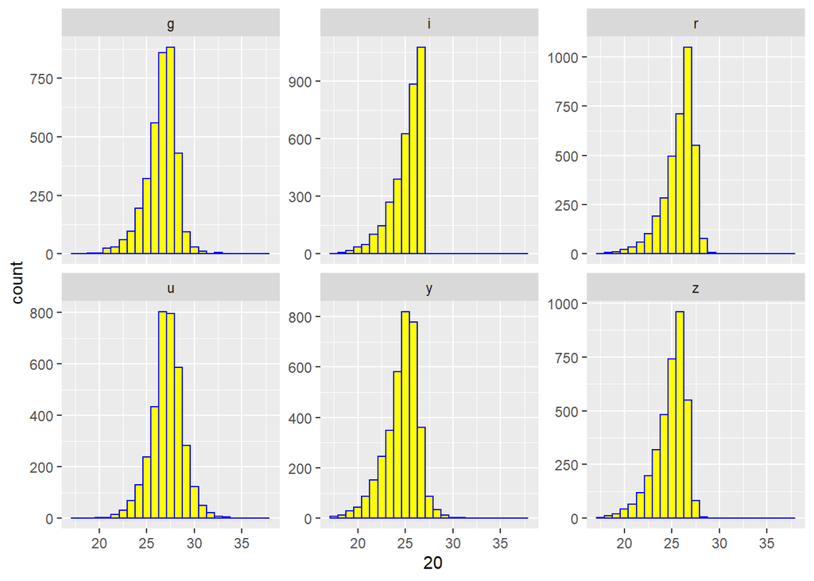

```r
# FILL ME IN
df_new <- df %>% dplyr::select(.,u, g, r, i, z, y) %>% gather(.)

ggplot(data=df_new,mapping=aes(x=value)) +
geom_histogram(color="blue",fill="yellow",bins=25,position='Identity') +
facet_wrap(~key,scales='free_y') +
scale_x_continuous(c(20,32))
```

```r
labs(x = 'Magnitude')
```

```
## $x
## [1] "Magnitude"
##
## attr(,"class")
## [1] "labels"
```

## Question 8

Use `geom_point()` to create a scatter plot of `redshift` vs. r-band magnitude. (Remember, one plots $y$ vs. $x$, so `redshift` will go on the $y$-axis here.) Make the point size 0.5, change the x-axis label to “r-band magnitude”, and change the y-axis label to “Redshift”. Oh, and add some color!

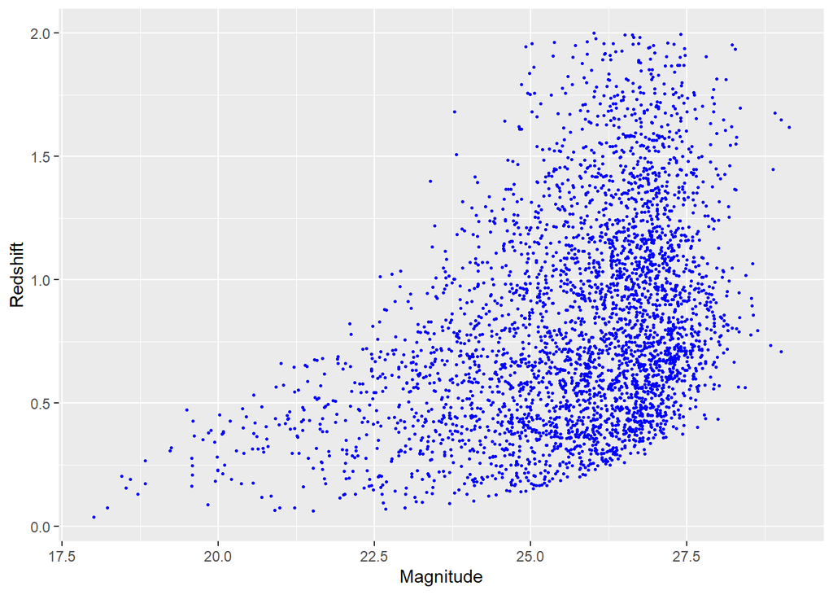

```r
# FILL ME IN
ggplot(data=df,mapping=aes(x=r,y=redshift)) +
geom_point(color="blue",size=0.5) +
labs(x ='Magnitude', y='Redshift')
```

## Question 9

Use the `corrplot()` function to assess the levels of correlation between the different columns of the `df` data frame, except `type`. Utilize the example in the notes. Note that you make need to install the `corrplot` package; you can do so by, e.g., typing `install.packages("corrplot")` in the Console, at the prompt. What should you see? That magnitudes are *very* highly correlated.

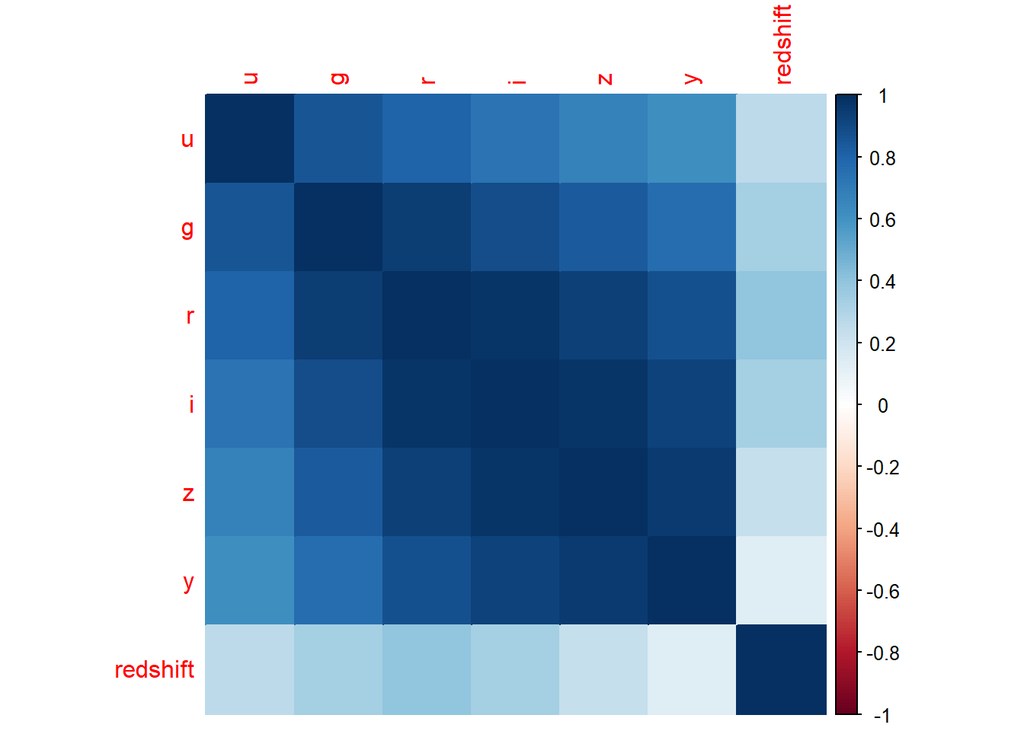

```r
# FILL ME IN

suppressMessages(library(corrplot))

df %>%
dplyr::select(.,u, g, r, i, z, y,redshift) %>%
cor(.) %>%
corrplot(.,method="color")
```

## Question 10

Repeat Question 9, but utilize `mutate()` to create five new variables: `ug`, the difference between `u` and `g`; `gr`, the difference between `g` and `r`; etc. Select only the five new variables, and plot the correlation plot. The new variables are dubbed *colors* and are often used by astronomers because they should only be a function of the physics of galaxies, as opposed to physics and distance. Ultimately, you should find that the correlation between colors is *far less* than the correlation between magnitudes.

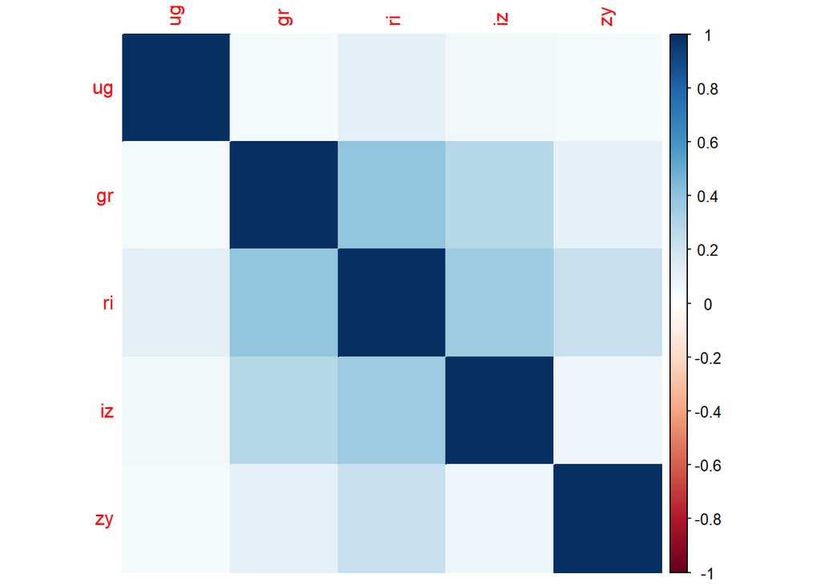

```r
# FILL ME IN
df %>%
  mutate(.,ug=u-g,gr=g-r,ri=r-i,iz=i-z,zy=z-y) -> df.newer

df.newer %>%
  dplyr::select(.,ug, gr, ri, iz, zy) %>%
  cor(.) %>% corrplot(.,method="color")
```